# Analysis of the Carpentry’s Long-Term Feedback Survey

[Kari L. Jordan](https://github.com/kariljordan)  
**May 2017**

# Introduction

Data and Software Carpentry launched a [long-term assessment survey](https://www.surveymonkey.com/r/carpentrieslongtermassessment) in March 2017. The goal of this survey was to hear from our learners about what has transpired in their work and career since completing a Carpentry workshop. Read our about our long-term assessment strategy on our [blog](http://www.datacarpentry.org/blog/long-term-assessment-strategy/) and see how the community was involved with the development of this survey.

A [PDF](https://github.com/carpentries/public-survey-info/blob/master/documents/surveys/2017-04-17-carpentry-long-term-feedback-survey.pdf) of the survey questions and the data used in this analysis are located in the [long-term feedback survey report](https://github.com/carpentries/public-survey-info/tree/master/documents/reports/Carpentry-Reports/Long-Term-Feedback-Survey-Report) folder on GitHub. We have already received several pull requests from community members interested in this data. Feel free to use the data and tell us about your findings.

This analysis includes 476 observations. Not all respondents answered each of the 26 questions.

# Highlights

Provided below are a few highlights from the data.

# Respondent Demographics

| Field | n |
| --- | --- |
| Life Sciences | 166 |
| Biomedical/Health Sciences | 95 |
| Agricultural or Environmental Sciences | 74 |
| Physical Sciences | 57 |
| Earth Sciences | 48 |
| Engineering | 41 |
| Mathematics or Statistics | 41 |
| Computer Science | 38 |
| Social Sciences | 24 |
| Library Sciences | 20 |
| Humanities | 12 |
| Business | 6 |

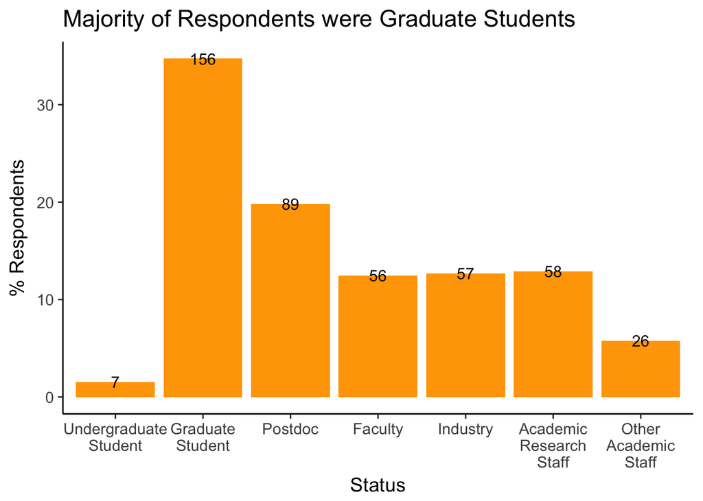

Carpentry workshops are open to individuals from all backgrounds and fields. Attendees vary from students (undergraduate and graduate) and faculty to staff and persons working in industry. 35% of our respondents were graduate students.

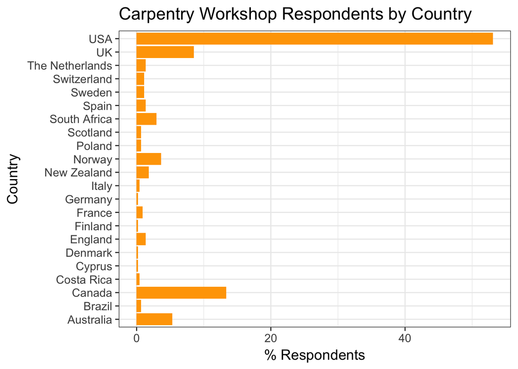

Provided is a breakdown of our respondents by the Country where they attended a Carpentry workshop. A large portion of Carpentry learners responding to the survey attended a workshop in the United States (53%), followed by Canada (13%) the UK (9%), and Australia (5%).

The Carpentries continue to endeavor to improve our workshop content and operations. We were therefore interested in knowing how many workshops respondents attended, and how long it has been since respondents completed a workshop. If there are spikes in the trends of our data, knowing when respondents completed a workshop will help us pinpoint whether or not our changes are related to learner responses in the data.

74% of respondents participated in a Carpentry workshop more than one year ago, and 84% of respondents have attended only one Carpentry workshop.

The majority of respondents attending a workshop more than one year ago speaks to their level of involvement with the Carpentries (120 people responded having subscribed to the Carpentries newsletter). It can be difficult, in survey research, to collect responses from participants a year later. It is great to see that learners are still receptive to our e-mail communication and have taken time to complete our survey.

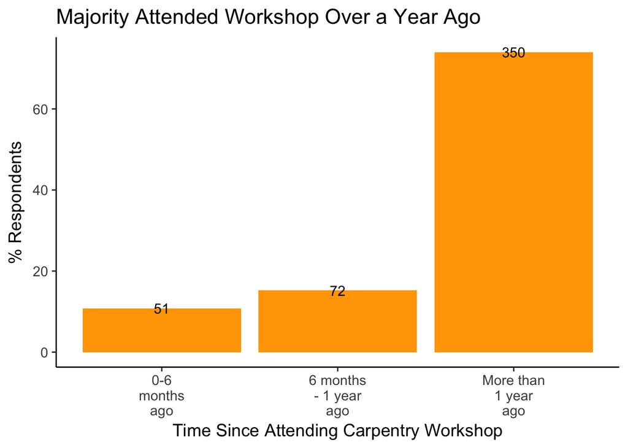

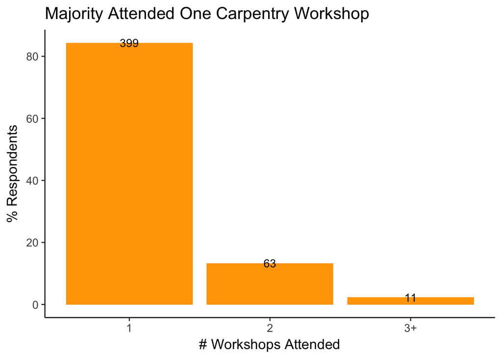

### Workshop Content

Data Carpentry’s [lessons](http://www.datacarpentry.org/lessons/) include data organization in Spreadsheets, data cleaning with OpenRefine, data management with SQL, and data analysis and visualization in R and Python.

Software Carpentry’s [lessons](https://software-carpentry.org) include the Unix Shell, version control with Git and Mercurial, programming with Python, R, and MATLAB, databases with SQL, and Automation and Make. Provided below is a breakdown of the tools respondents identified being covered in the workshop they attended.

| Content | n |
| --- | --- |
| Git | 362 |
| Python | 289 |
| Unix Shell | 274 |
| R | 186 |
| SQL | 134 |
| OpenRefine | 28 |
| Spreadsheets | 20 |
| Cloud Computing | 11 |
| MATLAB | 5 |
| Mercurial | 3 |

A large majority of respondents learned Git (n = 362), Python (n = 289), and Unix Shell (n = 274). On the low end were Spreadsheets (n = 20), Cloud Computing (n = 11), MATLAB (n = 5), and Mercurial (n = 3). OpenRefine, Spreadsheets, and Cloud Computing being on the low end is an indicator that the majority of our respondents attended a Software Carpentry workshop. This makes sense as Software Carpentry has offered more workshops than Data Carpentry.

### Programming Usage Pre- and Post Workshop

A goal for this assessment is to understand respondents’ programming usage before attending a Carpentry workshop compared to after. Our hope is that the workshop they attended influenced their usage of the programming tools they learned.

The plot below is a comparison of respondents’ usage of the tools covered in their workshop before completing the workshop versus after.

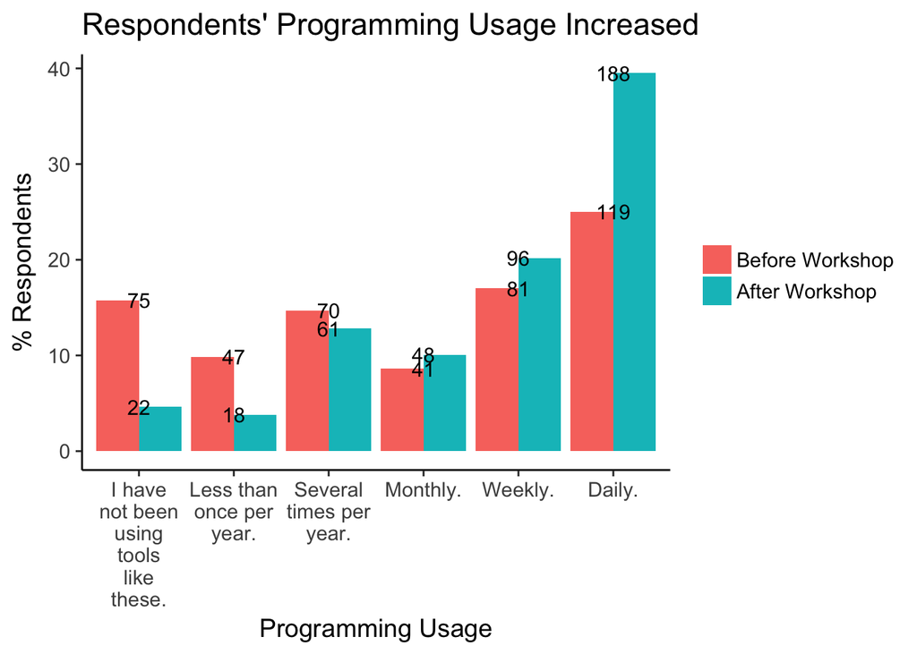

The most compelling change in responses was a decline in the percentage of respondents that ‘have not been using these tools’ (-11.1%), and an increase in the percentage of those who now use the tools on daily basis (14.5%).

# Workshop Impact

Respondents were asked to reflect on ways in which completing a Carpentry workshop may have impacted them by rating their level of agreement (1-Strongly disagree to 5-Strongly agree) with the following statements:

- I have used skills I learned at the workshop to advance my career.
- I have been motivated to seek more knowledge about the tools I learned at the workshop.
- I have made my analyses more reproducible as a result of completing the workshop.
- I have received professional recognition for my work as a result of using the tools I learned at the workshop.
- I have improved my coding practices as a result of completing the workshop.
- My research productivity has improved as a result of completing the workshop.
- I have gained confidence in working with data as a result of completing the workshop.

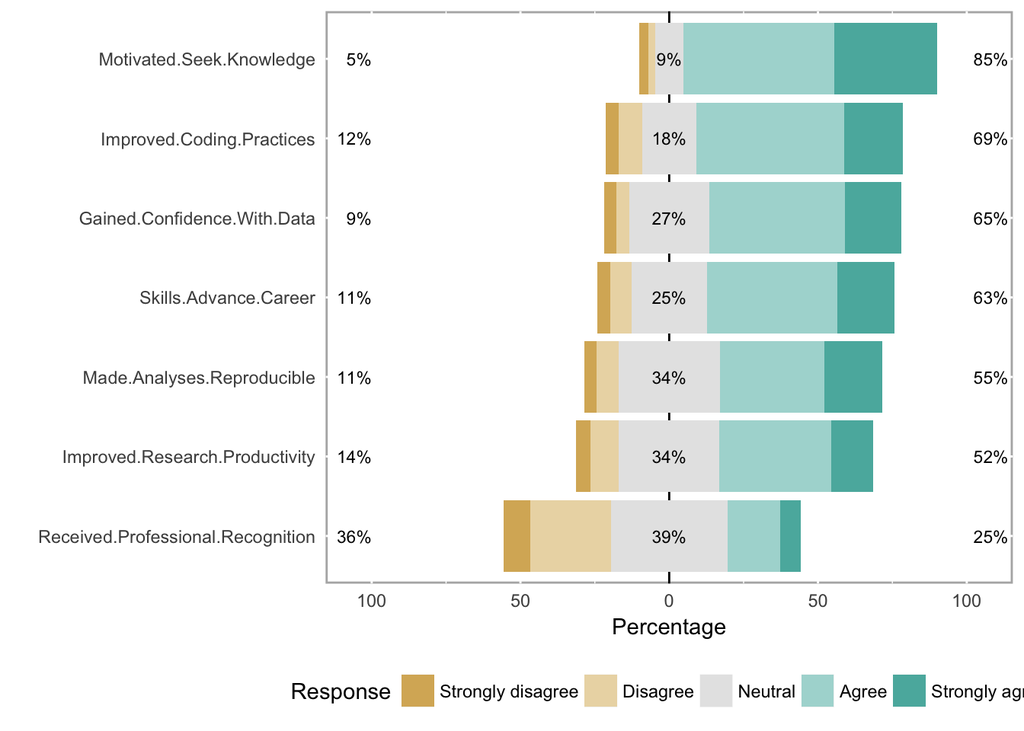

### Behaviors Adopted

We asked respondents to identify the behaviors they adopted as a result of completing a Carpentry workshop. We are happy to report that more than half of the respondents who answered this question (n= 361) have improved their data management and project organization practices, used programming languages for automation, and used version control to manage code. Additionally, respondents are **more confident** now in using the tools than before they completed a Carpentry workshop.

| Behaviors | n |
| --- | --- |
| Using programming languages like R or Python, or the command line to automate repetitive tasks. | 260 |
| Improving data management and project organization. | 198 |
| Using version control to manage code. | 185 |
| Reusing code. | 169 |
| Sharing code or data publicly on places like GitHub or FigShare. | 122 |
| Using databases, scripts and queries to manage large data sets. | 119 |
| Using version control to collaborate online (in public or private repositories). | 119 |
| Transforming step-by-step workflows into scripts or functions. | 111 |
| Developing a data management and analysis plan. | 74 |

### Change in Confidence

Our goal is for learners to leave a workshop having an increase in their confidence to use the tools they learned. More than 75% of the respondents are more confident now in using the tools they learned than they were before attending a Carpentry workshop.

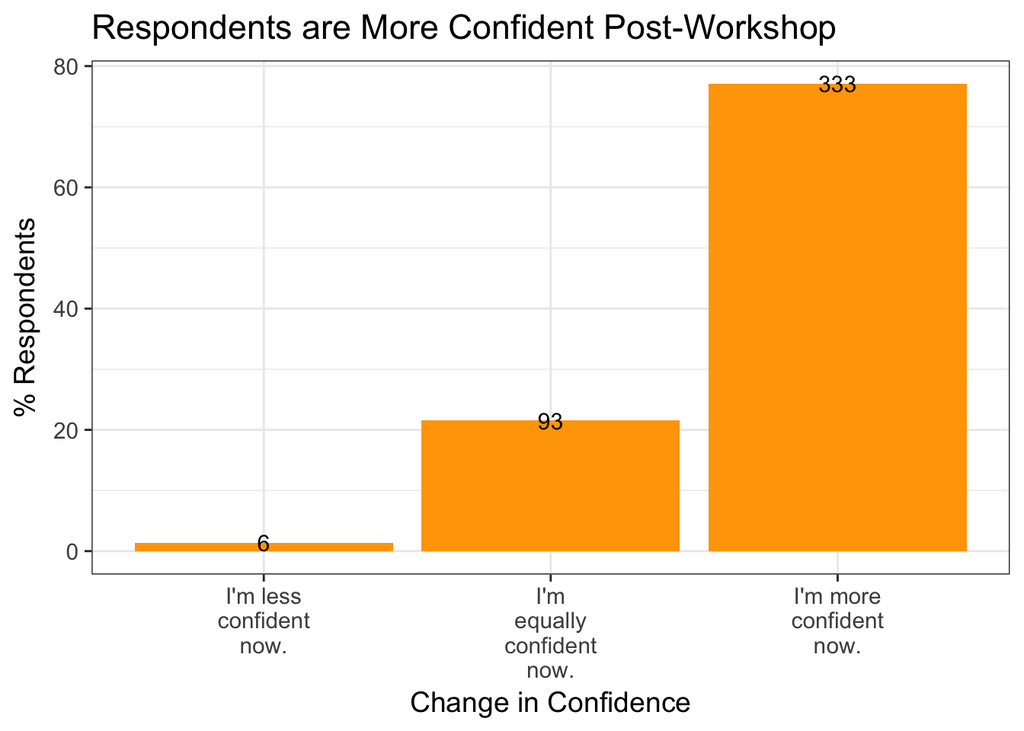

### Usage of Tools for Research and/or Work

We identified specific outcomes that learners may experience after completing a Carpentry workshop that are directly related to their research and/or work. Respondents have identified that the tools they learned improved their overall efficiency, and ability to manage and analyze data.

| How Tools Covered Have Helped | n |
| --- | --- |
| They are improving my overall efficiency. | 245 |
| They are improving my ability to analyze data. | 217 |
| They are improving my ability to manage data. | 203 |
| I am not using the tools I learned. | 61 |
| The tools I learned have not helped me with my work. | 28 |

### Contributions to Academic Writing

Another possible outcome of attending a Carpentry workshop is that the tools learned may contribute to academic writing (i.e. grant proposal, journal article).

| Have the Tools Learned Contributed to Academic Writing? | % |
| --- | --- |
| No. | 44 |
| Not sure. | 28 |
| Yes. | 27 |

### Continuous Learning

One of our primary outcomes is that learners continue on in their learning once they’ve completed a workshop. This can take many forms including participating in short-courses (in-person and online) and using self-guided material. We asked respondents to tell us which learning activities (for data management and analysis) they’ve participated in since completing a Carpentry workshop. The majority of respondents have used non-Carpentry self-guided material, though 68 responded having used Carpentry self-guided material. Additionally, we see participation in meetups and in-person short courses.

| Continuous Learning | n |
| --- | --- |
| Used non-Carpentry self-guided material. | 127 |
| Used self-guided Carpentry lesson material. | 68 |
| Participated in an in-person short course. | 59 |
| Participated in an online short course. | 45 |
| Participated in a Meetup. | 35 |
| Participated in a semester long course. | 24 |

## Involvement in the Carpentries

Another outcome of attending a Carpentry workshop is that learners become involved with Software and/or Data Carpentry by way of joining a mentoring group, becoming a workshop helper, or even becoming an instructor. The table provided below shows how respondents have been involved with the Carpentries since completing a workshop. Respondents were asked to check all that apply.

| Involvement Since Attending a Carpentry Workshop | n |
| --- | --- |
| Subscribed to the newsletter. | 120 |
| Became a workshop helper. | 31 |
| Became a Carpentry instructor. | 26 |
| Attended at least one community call. | 18 |
| Contributed to a Carpentry lesson. | 18 |
| Joined a mentoring group. | 12 |
| Participated in a Twitter chat. | 11 |
| Joined a committee. | 6 |

# Summary

We value our learners because when they have successful experiences in our workshops, they share their experience with others. We asked respondents if they had already recommended our workshop, and 74% said yes!

This initial look at how Carpentry workshops have impacted learners long-term has been extremely insightful. In general, our workshops are helping learners improve their efficiency with managing and analyzing data. Learners are taking advantage of online resources to improve their skills, and becoming involved with our community.

We will take another look at this data to compare responses of learners having taken a workshop more than a year ago versus those having taken a workshop 0 to 6 months ago and 6 months to 1 year ago. Additionally, every 6 months we will collect data using this survey from new learners to see how they’re doing.